# tss-uncertainty-stan

A.J. Brown

2024-01-28

# Bayesian Inference for TSS Measurement Uncertainty

By A.J. Brown Agricultural Data Scientist ansleybrown1337@gmail.com [Personal Website](https://sites.google.com/view/ansleyjbrown/)

Description: This script is used to perform Bayesian inference on TSS using the [Stan](https://mc-stan.org/rstan/) and [rethinking](https://github.com/rmcelreath/stat_rethinking_2023) packages in R. For more information please view the README.md file in the root directory of [this repository](https://github.com/ansleybrown1337/bayes-tss-uncertainty).

I’ve decided to add this script to re-attempt this problem after informally auditing Richard McElreath’s, [Statistical Rethinking 2023](https://www.youtube.com/playlist?list=PLDcUM9US4XdPz-KxHM4XHt7uUVGWWVSus) course. As such, my methodology has changed a bit, and this script will likely be my ‘main’ script moving forward, with my NIMBLE code for reference.

## Table of Contents

1. Load packages and data
2. Defining a causal model (i.e., the DAG)
3. Defining a statistical model
4. Defining a likelihood function using Stan
5. Results

## Load packages and data

```r
# Set working directory to repo parent folder
# Remember to make the knit button knit from current working directory
#setwd('../')
```

```r
# Load data
tss_df <- read.csv('../Example Data/TSS_Master_2023.csv')
```

```r
# Process data
  # Clean up tss_df first
  tss_df <- tss_df %>%
    select( # drop unnecessary columns
      Batch_no,
      Sample_ID,
      Lab_technicians,
      TSS_mg.L,
      Notes
    )

  # separate data into two dataframes: standards and real data
    # standard solution df
    std_list <- c('Stock Solution', 'DI')
    std_df <- tss_df %>%
      filter( # filter out real samples
        Sample_ID %in% std_list
      ) %>%
      mutate( # calculate error from known standard values (100 or 0 ppm)
        tss.err = ifelse(
          Sample_ID == 'Stock Solution', 100-TSS_mg.L, 0-TSS_mg.L
        )
      ) %>%
      mutate( # make factors into number cols for ulam() later
        Sample_ID.num = as.numeric(as.factor(Sample_ID)),
        Lab_technicians.num = as.numeric(as.factor(Lab_technicians))
      )
    # real samples df
    real_df <- tss_df %>% filter(!Sample_ID %in% std_list)

  # NOTE: it is not usually a good practice to estimate constructed variables
  # (like tss error) instead of the raw output variables (i.e., TSS, mg/L).
  # Specifically, calculating TSS error here assumes linear relationship between
  # tss units and standard solutions, which may not be the case. See
  # https://youtu.be/hnYhJzYAQ60?si=J4CNqn2COmnFTgpE&t=3366
  # HOWEVER, since we know the exact error by using standard solutions, it might be appropriate? I'll come back to this someday...
```

## Defining a causal model

DAG stands for Directed Acyclic Graph, which is a graphical representation of the causal relationships among variables. DAGs identify the sources of confounding relationships, selection bias, and mediation in our data. The causal model facilitates the construction of of a statistical model.

Here is the DAG created for this dataset:

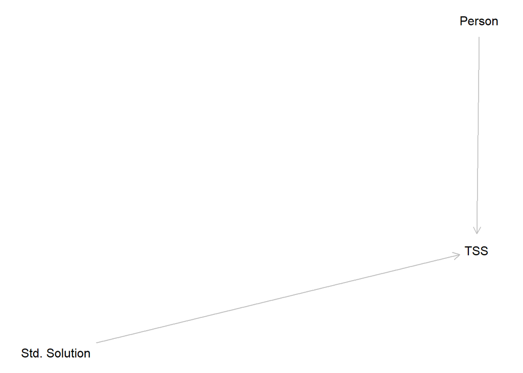

```r
# Create DAG from https://www.dagitty.net/
g <- dagitty('dag{
  bb="-3.196,-3.548,3.094,2.204"
  "Std. Solution" [exposure,pos="-2.672,1.349"]
  "TSS" [outcome,pos="0.043,-0.004"]
  Person [exposure,pos="0.059,-3.048"]
  "Std. Solution" -> "TSS"
  Person -> "TSS"
}'
)
plot(g)
```

The DAG shown here illustrates two covariates, Person and Std. Solution, and their causal effect on TSS error as known from the use of D.I. Water (0 ppm) and standard solution (100 ppm). In this case, the analysis will focus on identifying the causal effect of person (i.e., lab technician) on TSS error, clustering by standard solution type. This will allow partial pooling of variance, which may differ depending on the standard solution used to quantify error.

## Defining a statistical model

We will use simple linear regression to estimate measurement error. I will assume the following form:
$$TSSerr_{i}
= \alpha_S + \beta_{P} * Person$$
$$\alpha_S \sim N(\bar{\alpha}, \sigma)$$
$$\alpha \sim N(0, 1.5)$$
$$\sigma \sim \exp(1)$$

Where: - $TSSerr_{i}$ is the error in TSS measurement $i$  
- $\alpha_S$ is the intercept for standard solution $S$  
- $\beta_{P}$ is the coefficient for each lab technician effect

## Defining a likelihood function

```r
# create data vector
dat <- list(
  E = std_df$tss.err,
  P = std_df$Lab_technicians.num,
  S = std_df$Sample_ID.num
)

# create function using Stan
mTSS <- ulam(
    alist(
        E ~ dnorm(mu, sigma),
        sigma ~ dexp(1),
        mu <- a[S] + bP[P],
        bP[P] ~ dnorm(0, 0.5),
        a[S] ~ dnorm(a_bar, sigma_a),
        a_bar ~ dnorm(0, 1.5),
        sigma_a ~ dexp(1)
    ), data=dat , chains=4, cores = 4)
```

[output not shown]

[output not shown]

[output not shown]

[output not shown]

[output not shown]

[output not shown]

[output not shown]

```
## Chain 2
```

[output not shown]

## Results

### Model Convergence and Summary

```r
precis(mTSS, depth = 2)
```

```
##                mean        sd       5.5%     94.5%     rhat  ess_bulk
## sigma    4.01244185 0.2973660  3.5732699 4.5164851 1.000258 1647.0414
## bP[1]   -0.18286817 0.4313595 -0.8977526 0.4936243 1.001384 1215.2883
## bP[2]    0.11480683 0.4669985 -0.6011926 0.8650471 1.000951 1397.3275
## bP[3]    0.06901001 0.4224020 -0.6146091 0.7318445 1.000004 1332.0277
## a[1]     0.48668784 0.5984399 -0.4704423 1.5092668 1.002716  914.5470
## a[2]    -0.14217103 0.6086062 -1.1372701 0.7830506 1.001345  831.2176
## a_bar    0.11837961 0.6910184 -1.0032735 1.1223019 1.002830  838.1745
## sigma_a  0.76123155 0.6139782  0.1067390 1.9097913 1.000780  437.2076
```

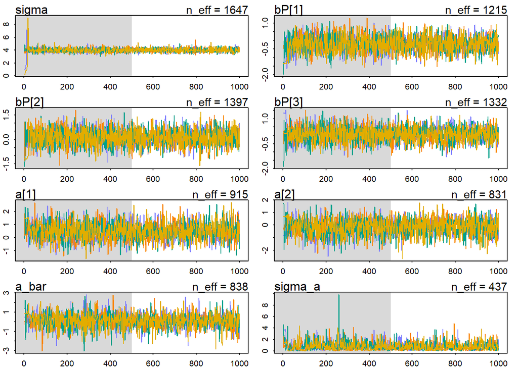

```r
traceplot(mTSS, n_cols=2, lwd=1)
```

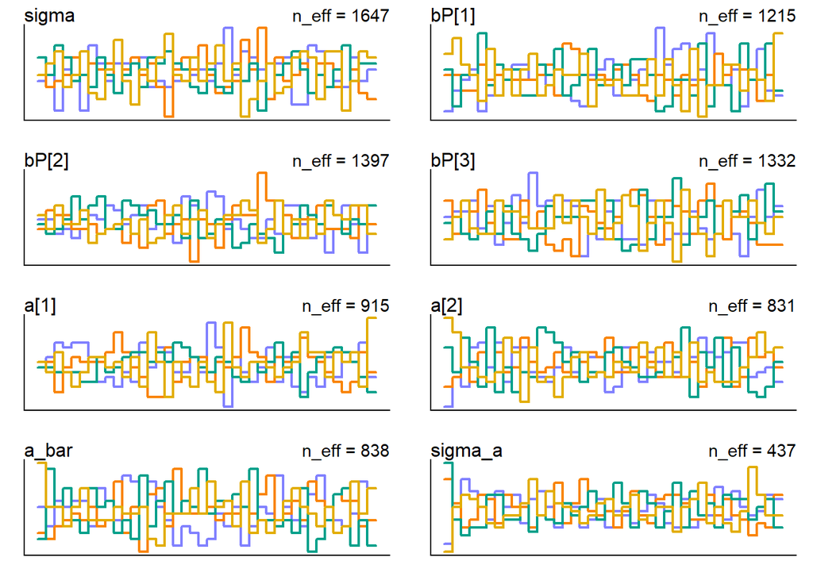

```r
trankplot(mTSS, n_cols=2, lwd=2)
```

### Posterior Predictions and Summary

```r
post <- extract.samples(mTSS)
```

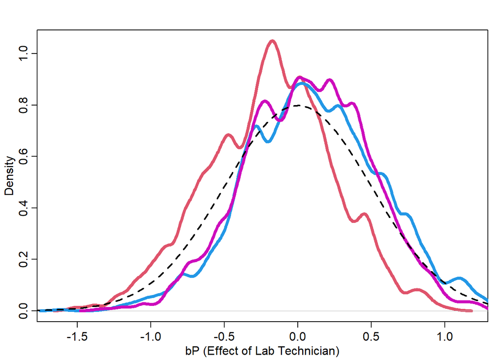

```r
# create df of bP levels
bP_df <- as.data.frame(post$bP)

# Plot densities
dens(bP_df$V1, lwd=4, col=2, xlab="bP (Effect of Lab Technician)")
dens(bP_df$V2, lwd=4, col=4, xlab="bP (Effect of Lab Technician)", add=TRUE)
dens(bP_df$V3, lwd=4, col=6, xlab="bP (Effect of Lab Technician)", add=TRUE)

# Plot the prior distribution
# Define the range for x_seq based on the values in bP_df
x_seq <- seq(from = min(bP_df) - 1, to = max(bP_df) + 1, length.out = 300)

# Calculate the prior density
prior_dens <- dnorm(x_seq, mean = 0, sd = 0.5)

# Add the prior distribution to the plot
lines(x_seq, prior_dens, lwd = 2, col = "black", lty = 2)
```

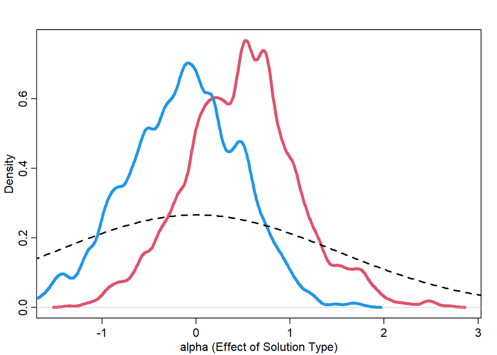

```r
# create df of alpha levels
a_df <- as.data.frame(post$a)


# Plot densities
dens(a_df$V1, lwd=4, col=2, xlab="alpha (Effect of Solution Type)")
dens(a_df$V2, lwd=4, col=4, xlab="alpha (Effect of Solution Type)", add=TRUE)

# Define the range for x_seq based on the values in bP_df
x_seq <- seq(from = min(a_df) - 1, to = max(a_df) + 1, length.out = 300)

# Calculate the prior density
prior_dens <- dnorm(x_seq, mean = 0, sd = 1.5)

# Add the prior distribution to the plot
lines(x_seq, prior_dens, lwd = 2, col = "black", lty = 2)
```

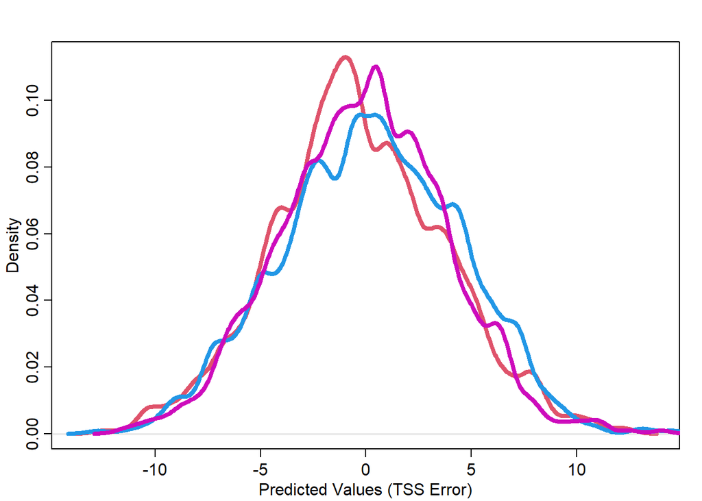

```r
# Step 1: Generate Posterior Predictions
post_pred <- sim(mTSS, n=5000)

# Convert post_pred to a dataframe
post_pred_df <- as.data.frame(post_pred)

# Assuming there are 3 lab technicians and each column in post_pred_df corresponds to one
# Step 2: Stratify Predictions by Lab Technicians
# Use the dataframe columns directly for each technician
pred_technician1 <- post_pred_df[[1]]
pred_technician2 <- post_pred_df[[2]]
pred_technician3 <- post_pred_df[[3]]

# Step 3: Graph the Densities
dens(pred_technician1, lwd=4, col=2, xlab="Predicted Values (TSS Error)")
dens(pred_technician2, lwd=4, col=4, xlab="Predicted Values (TSS Error)", add=TRUE)
dens(pred_technician3, lwd=4, col=6, xlab="Predicted Values (TSS Error)", add=TRUE)
```

```r
# Function to compute summary statistics
compute_summary <- function(predictions) {
    list(
        mean = mean(predictions),
        sd = sd(predictions),
        quantile_2.5 = quantile(predictions, probs = 0.025),
        quantile_97.5 = quantile(predictions, probs = 0.975)
    )
}

# Calculate summary statistics for each technician
summary_technician1 <- compute_summary(pred_technician1)
summary_technician2 <- compute_summary(pred_technician2)
summary_technician3 <- compute_summary(pred_technician3)


# Combine summaries into a data frame
summary_df <- data.frame(
    Technician = c("Technician 1", "Technician 2", "Technician 3"),
    Mean = c(summary_technician1$mean, summary_technician2$mean, summary_technician3$mean),
    SD = c(summary_technician1$sd, summary_technician2$sd, summary_technician3$sd),
    Quantile_2.5 = c(summary_technician1$quantile_2.5, summary_technician2$quantile_2.5, summary_technician3$quantile_2.5),
    Quantile_97.5 = c(summary_technician1$quantile_97.5, summary_technician2$quantile_97.5, summary_technician3$quantile_97.5)
)


print(summary_df)
```

```
##     Technician        Mean       SD Quantile_2.5 Quantile_97.5
## 1 Technician 1 -0.32900292 4.082767    -8.255792      8.000991
## 2 Technician 2  0.24705703 4.218249    -7.727902      8.155937
## 3 Technician 3 -0.09630859 3.895590    -7.534179      7.220819
```